# Evaluación curso R

QUIRALTE PULIDO, MIGUEL

## Entrega

- Recuerda completar tu **nombre en el apartado author**.
- Además del código, no olvides completar las respuestas a las preguntas indicadas en negrita.
- Si tienes dudas/dificultades, **puedes contactar con los profesores**.
- Deadline: **viernes 10 de junio, 23:59**.
- Puedes realizar la entrega en el mail: **constantino.garciama@ceu.es**.
- La entrega consistirá en este fichero rellenado y el fichero que se genera al hacer `Knit` (un fichero `Rmd` y un fichero `html`).

## Apuestas de adolescentes en UK

El conjunto de datos `teengamb.csv` contiene datos sobre las tasas de juego entre los adolescentes en Gran Bretaña, su género y estatus socioeconómico. Una pregunta que nos puede interesar es cómo se relacionan el género y los ingresos con cuánto juega una persona (céntrate solo en las variables `income`, `sex` y `gamble`)… Sigue los siguientes pasos para crear un ANCOVA…

```r
knitr::opts_chunk$set(echo = TRUE)
```

## instalación paquetes

```r
library(dbplyr)
library(tidyverse)
library("emmeans")
library("performance")
library("effectsize")
```

### 1) Carga y visualiza los datos…

…para valorar si el modelo debe incluir interacciones. Escribe claramente tus conclusiones

```r
teengamb_csv = read.csv("teengamb.csv") #cargar archivo .csv
teengamb_csv
```

```
##       sex status income verbal      gamble
## 1  Female     51   2.00      8  20.9658052
## 2  Female     28   2.50      8 -11.0915144
## 3  Female     37   2.00      6  -8.5867626
## 4  Female     28   7.00      4  17.3517324
## 5  Female     65   2.00      8 -17.2524094
## 6  Female     61   3.47      6  14.8785327
## 7  Female     28   5.50      7 -20.7981197
## 8  Female     27   6.42      5 -15.7438197
## 9  Female     43   2.00      6  12.1798893
## 10 Female     18   6.00      7  -4.0634685
## 11 Female     18   3.00      6  24.2939832
## 12 Female     43   4.75      6  -2.6985100
## 13 Female     30   2.20      4   0.9663439
## 14 Female     28   2.00      6  -1.8934788
```

[output cut: 33 more lines]

```r
head(teengamb_csv)
```

```
##      sex status income verbal     gamble
## 1 Female     51   2.00      8  20.965805
## 2 Female     28   2.50      8 -11.091514
## 3 Female     37   2.00      6  -8.586763
## 4 Female     28   7.00      4  17.351732
## 5 Female     65   2.00      8 -17.252409
## 6 Female     61   3.47      6  14.878533
```

```r
#tipo de variables
typeof(teengamb_csv$sex) #está en modo character
```

```
## [1] "character"
```

```r
typeof(teengamb_csv$income)
```

```
## [1] "double"
```

```r
typeof(teengamb_csv$gamble)
```

```
## [1] "double"
```

```r
#transformar sex en factor
teengamb_csv = mutate(teengamb_csv, sex = factor(sex))
typeof(teengamb_csv$sex)
```

```
## [1] "integer"
```

```r
#mostrar los niveles de la categoria "sex"
levels(teengamb_csv$sex)
```

```
## [1] "Female" "Male"
```

```
## No summary function supplied, defaulting to `mean_se()`
## No summary function supplied, defaulting to `mean_se()`
```

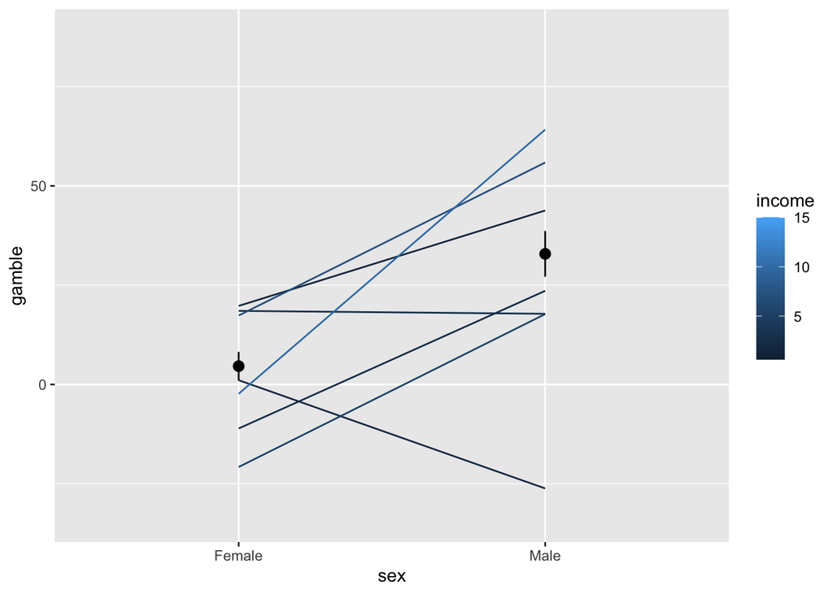

```r
ggplot(teengamb_csv, aes(x=sex, y=gamble, col=income)) +
  stat_summary() +
  stat_summary(geom='line', aes(group=income))
```

##Conclusiones sobre la necesidad de interacción: Sí hay interacciones entre los grupos, porque las líneas se entrecruzan en casi todos los casos. La relación entre el numero de apuestas y los ingresos se ve condicionada por el sexo.

En general, si las líneas se entrecruzan quiere decir que hay interacción. En el ejemplo, sí que hay interacción ya que las líneas de nuestra gráfica se entrecruzan.

Es decir, la apuesta de cada individuo depende de la interacción entre los ingresos y el sexo.

```
## No summary function supplied, defaulting to `mean_se()`
## No summary function supplied, defaulting to `mean_se()`
```

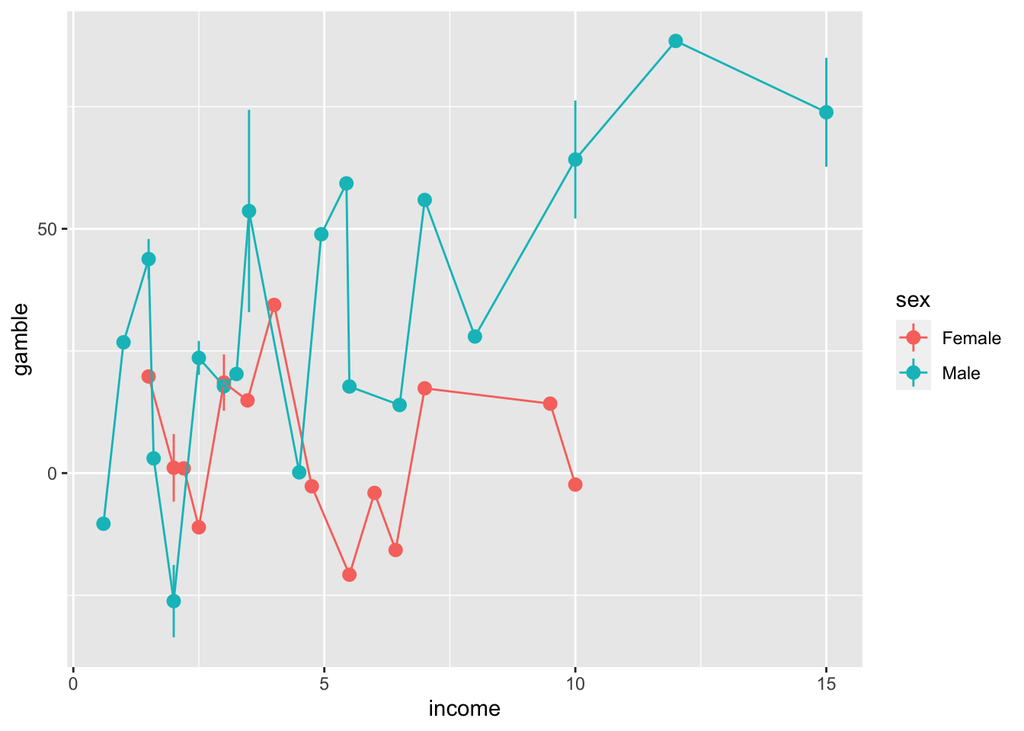

```r
ggplot(teengamb_csv, aes(x=income, y=gamble, col=sex)) +
  stat_summary() +
  stat_summary(geom='line', aes(group=sex))
```

Esta gráfica muestra que, en general, los hombres apuestan más que las mujeres cuanto mayores son sus ingresos.

### 2) Crea el modelo…

… y obtén:

- los intervalos de confianza para los coeficientes y su significación.
- Obtén los tamaños de los efectos.

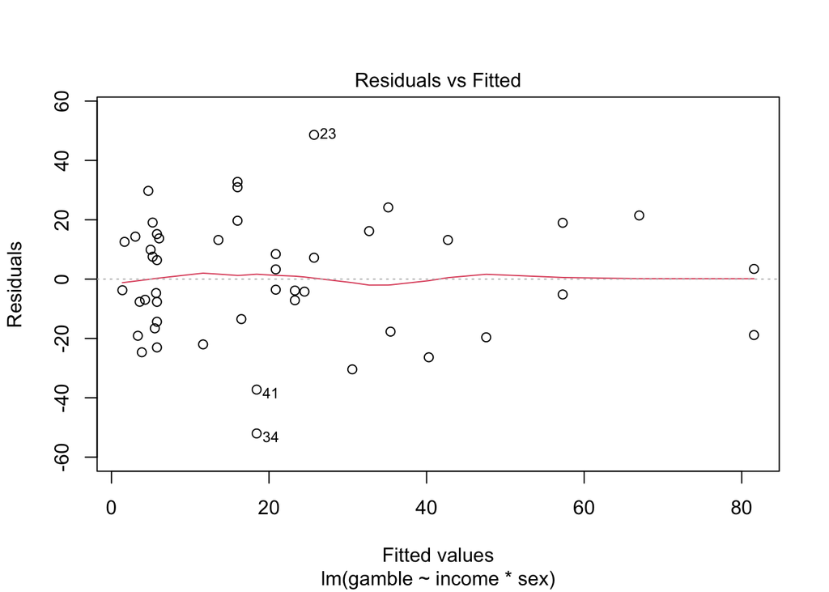

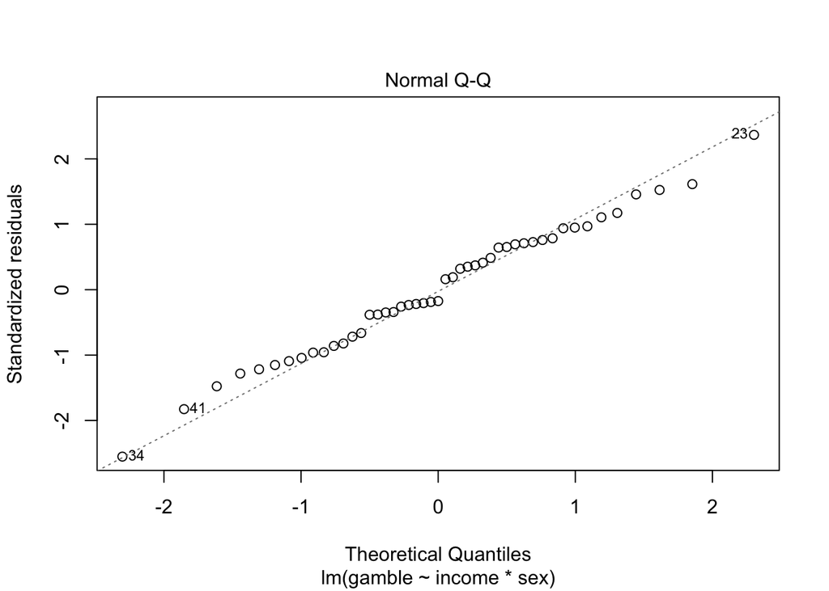

```r
##Creamos un modelo donde gamble depende de income y sex.
teen_lm = lm(gamble ~ income * sex, teengamb_csv)

##Representamos el Q-Q plot
plot(teen_lm, which = c(1, 2), ask = FALSE)
```

Nuestros datos se ajustan bien al modelo lineal.

## El modelo sigue una distribución normal.

```r
## Obtenemos un resumen de nuestro modelo, así como los intervalos de confianza y el tamaño del efecto.
summary(teen_lm) ## --> no da que gamble depende de la interacción entre sex e income, ya que la diferencia es significativa (0.0155)
```

```
##
## Call:
## lm(formula = gamble ~ income * sex, data = teengamb_csv)
##
## Residuals:
##     Min      1Q  Median      3Q     Max
## -52.025 -15.479  -3.559  14.022  48.625
##
## Coefficients:
##                Estimate Std. Error t value Pr(>|t|)
## (Intercept)      6.8743     9.2446   0.744   0.4612
## income          -0.5489     1.9024  -0.289   0.7743
## sexMale          1.8427    11.1946   0.165   0.8700
## income:sexMale   5.4050     2.1435   2.522   0.0155 *
## ---
## Signif. codes:  0 '***' 0.001 '**' 0.01 '*' 0.05 '.' 0.1 ' ' 1
##
## Residual standard error: 20.97 on 43 degrees of freedom
## Multiple R-squared:  0.5105, Adjusted R-squared:  0.4764
## F-statistic: 14.95 on 3 and 43 DF,  p-value: 8.279e-07
```

```r
confint(teen_lm)
```

```
##                     2.5 %    97.5 %
## (Intercept)    -11.769152 25.517839
## income          -4.385455  3.287728
## sexMale        -20.733425 24.418773
## income:sexMale   1.082260  9.727751
```

```r
effectsize(teen_lm)
```

```
## # Standardization method: refit
##
## Parameter      | Std. Coef. |         95% CI
## --------------------------------------------
## (Intercept)    |      -0.59 | [-0.93, -0.25]
## income         |      -0.07 | [-0.54,  0.40]
## sexMale        |       0.93 | [ 0.49,  1.37]
## income:sexMale |       0.66 | [ 0.13,  1.19]
```

### 3) Interpreta los coeficientes y escribe tus conclusiones.

Los ingresos y el sexo no tienen un efecto por sí solo sobre la apuesta que se realiza ya que los intervalos de confianza pasan por el 0 [-4.385455, 3.28772] (income) y [-20.733425, 24.418773] (sex). Sin embargo, los intervalos de confianza de la interacción de los ingresos-sexo están por encima de 0, por tanto sí que hay un efecto de esta interacción sobre la apuesta que se realiza [1.082260, 9.727751].

### 4) Crea un gráfico con las predicciones de tu modelo…

…y compáralas con los datos reales.

```r
teengamb_csv$predictions = predict(teen_lm) ## --> añadimos una columna con las predicciones al csv.
head (teengamb_csv)
```

```
##      sex status income verbal     gamble predictions
## 1 Female     51   2.00      8  20.965805    5.776616
## 2 Female     28   2.50      8 -11.091514    5.502184
## 3 Female     37   2.00      6  -8.586763    5.776616
## 4 Female     28   7.00      4  17.351732    3.032296
## 5 Female     65   2.00      8 -17.252409    5.776616
## 6 Female     61   3.47      6  14.878533    4.969786
```

```
## No summary function supplied, defaulting to `mean_se()`
## No summary function supplied, defaulting to `mean_se()`
```

```
## geom_path: Each group consists of only one observation. Do you need to adjust
## the group aesthetic?
```

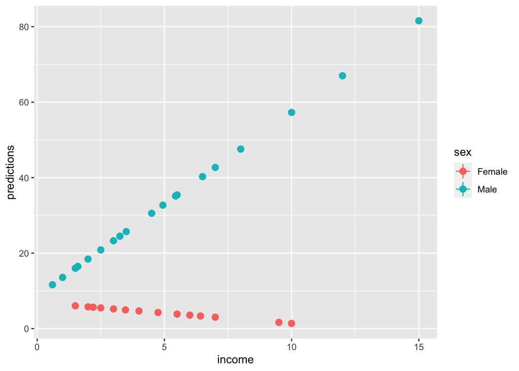

```r
ggplot(teengamb_csv, aes(x=income, y=predictions, col=sex)) +
  stat_summary() +
  stat_summary(geom='line', aes(group=income))
```

**¿Es bueno el ajuste?:**

Por tanto, no se ajusta del todo bien el modelo predictor a los datos reales

### 5) Valora si las asunciones del modelo se cumplen

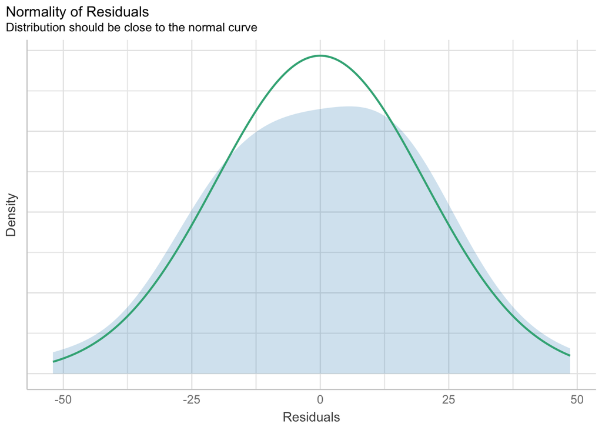

```r
teen_lm_norm = check_normality(teen_lm)

plot(teen_lm_norm)
```

```
## For confidence bands, please install `qqplotr`.
```

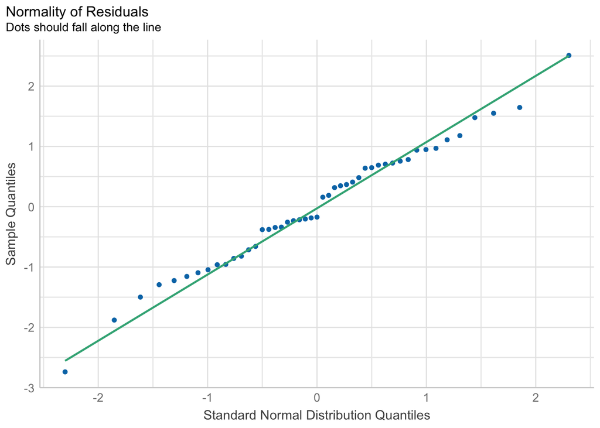

```r
plot(teen_lm_norm, type = "qq")
```

```
## For confidence bands and detrending, please install `qqplotr`.
```

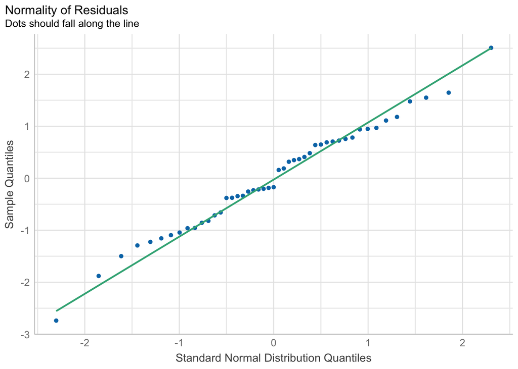

```r
plot(teen_lm_norm, type = "qq", detrend=TRUE)
```

**¿Es el modelo correcto?:**

El modelo es bueno, ya que se ve que hay normalidad, pero la predicción no es muy buena, ya que en los hombres sí se ve bien esa tendencia a apostar más cuanto más ingresos tienen como se ve en nuestros datos, pero no te lo predice del todo bien en las mujeres.